# Assignment 4: Movie Review Analysis [50 Pt]

### Part (v) [1pt EXPLORATORY]

Select a single sample from your training DataLoader and feed it through the **bert_model** to obtain the hidden_states and pooled_output. Briefly describe what each tensor dimension represents and what affects the size of each dimension.

```python
# TO BE COMPLETED

#single sample from traning dataLoader
for attr in train_data_loader:
    sample = attr  # Retrieve one attribute
    break  # Break after loading one batch

# Choose a single sample index from the batch
single_sample_index = 0

# Get input_ids and attention_mask for the single sample
input_ids = sample['input_ids'][single_sample_index].unsqueeze(0)  # Add batch dimension
attention_mask = sample['attention_mask'][single_sample_index].unsqueeze(0)  # Add batch dimension

# Forward pass through the BERT model to obtain hidden states and pooled output
with torch.no_grad():
    outputs = bert_model(input_ids, attention_mask=attention_mask)

print(f"First sample: {outputs[0]}")
hidden_states = outputs.last_hidden_state
pooled_output = outputs.pooler_output

print('Hidden state:', hidden_states)
print('Hidden state shape:', hidden_states.shape)

print('Pooled output:', pooled_output)
print('Pooled output shape', pooled_output.shape)
```

[output not shown]

[output cut: 115 more lines]

[output not shown]

```python
'''
PROVIDE YOUR ANSWER BELOW

hidden_states Tensor Dimensions:
torch.Size([1, 400, 768])
- 1 represent first the batch size (I got just one sample)
- 400 sequence Length: Denotes the maximum sequence length of the input text
      (determined by the MAX_LEN parameter when tokenizing).
- 768 hidden Size: Refers to the dimensionality of the hidden states in the BERT model


pooled_output Tensor Dimensions:
torch.Size([1, 768])
- 1. batch size (one sample)
- 768 Hidden Size: Dimensionality of the hidden states in the BERT model

it is possible to adjust the the batch size or sequence length during tokenization
and affects the size of the respective dimensions in the output tensors.
The hidden size and the number of layers are fixed for a particular BERT model
variant and cannot be altered after the model is trained
'''
```

## Part 2. Model Architecture [2 pt]

### Part (i) [1pt MODEL]

Prepare a review classifier model that builds on the pooled output from the Bert model to identify positive and negative reviews.

```python
# Set device to GPU if available
device = torch.device("cuda" if torch.cuda.is_available() else "cpu")
```

```python
import torch
import torch.nn as nn
from transformers import BertModel

class SentimentClassifierPooled(nn.Module):

  def __init__(self, n_classes):
    super(SentimentClassifierPooled, self).__init__()
    self.name = 'Pooled'
    self.bert = BertModel.from_pretrained(PRE_TRAINED_MODEL_NAME).to(device)
    self.drop = nn.Dropout(p=0.5)  # Add dropout layer for regularization
    self.out = nn.Linear(in_features=768,out_features=n_classes)
    self.softmax = nn.Softmax(dim=1)


  def forward(self, input_ids, attention_mask):
    pooled_output = self.bert(input_ids=input_ids, attention_mask=attention_mask)[1]
    output = self.drop(pooled_output)  # Applying dropout to pooled output
    output = self.out(output)  # Passing through a linear layer
    return self.softmax(output)  # Applying softmax to obtain class probabilities
```

### Part (ii) [1pt MODEL]

Construct the architecture for a review classifier model that uses the last hidden output from the Bert model to identify positive and negative reviews.

```python
class SentimentClassifierLast(nn.Module):
    def __init__(self, n_classes):
        super(SentimentClassifierLast, self).__init__()
        self.name = 'Last'
        self.bert = BertModel.from_pretrained(PRE_TRAINED_MODEL_NAME).to(device)
        self.drop = nn.Dropout(p=0.5)  # Adding a dropout layer for regularization
        self.out = nn.Linear(self.bert.config.hidden_size, n_classes)
        self.softmax = nn.Softmax(dim=1)

    def forward(self, input_ids, attention_mask):
        output = self.bert(input_ids=input_ids, attention_mask=attention_mask)
        #print(output)
        last_hidden_state = output.last_hidden_state  # Extracting last hidden states
        pooled_output = last_hidden_state[:, 0, :]  # Extracting the [CLS] token representation
        output = self.drop(pooled_output)  # Applying dropout to the last hidden state
        output = self.out(output)  # Passing through a linear layer
        return self.softmax(output)
```

## Part 3. Training [3 pt]

### Part (i) [1pt MODEL]

Complete the `get_accuracy` function, which will compute the accuracy (rate) of your model across a dataset (e.g. validation set).

```python
def get_accuracy(model, data):
    """ Compute the accuracy of the `model` across a dataset `data`

    Example usage:

    >>> model = MyRNN() # to be defined
    >>> get_accuracy(model, valid_loader) # the variable `valid_loader` is from above
    """
    model.eval()  # Set the model to evaluation mode

    correct, total = 0, 0

    with torch.no_grad():
        for batch in data:
            input_ids = batch['input_ids']
            attention_mask = batch['attention_mask']
            targets = batch['targets']

            # Forward pass
            outputs = model(input_ids, attention_mask)
            _, predicted = torch.max(outputs, dim=1)

            # Calculate total and correct predictions
            total += targets.size(0)
            correct += (predicted == targets).sum().item()

    acc = correct / total
    # TO BE COMPLETED
    return acc
```

### Part (ii) [1pt MODEL]

Write a function **train_model** to train your model. Plot the training curve of your final model. Your training curve should have the training/validation loss and accuracy plotted periodically.

```python
# TO BE COMPLETED

import torch
import torch.nn as nn
import matplotlib.pyplot as plt
import numpy as np

def train_network_B(model, bs, train_loader, valid_loader,n_model,lr,num_epochs=5):
    # prepare data loaders
    MAX_LEN = 400
    BATCH_SIZE = bs #<-it was too slow with 16

    #training data
    train_data = MovieReviewDataset(reviews=df_train['review'].to_numpy(),
                                    targets=df_train['sentiment'].to_numpy(),
                                    tokenizer=tokenizer,
                                    max_len=MAX_LEN)

    train_data_loader = DataLoader(train_data, batch_size = BATCH_SIZE, num_workers = 4) #modify num_works as needed

    #validation data

    # TO BE COMPLETED
    #training data
    val_data = MovieReviewDataset(reviews=df_val['review'].to_numpy(),
                                    targets=df_val['sentiment'].to_numpy(),
                                    tokenizer=tokenizer,
                                    max_len=MAX_LEN)

    val_data_loader = DataLoader(val_data, batch_size = BATCH_SIZE, num_workers = 4) #modify num_works as needed

    model.to(device)
    valid_loss_min = np.Inf
    clip = 5
    # Define loss function and optimizer
    optimizer = torch.optim.Adam(model.parameters(), lr=lr)
    criterion = nn.CrossEntropyLoss()  # For classification tasks
    # train for some number of epochs
    train_losses = []
    valid_losses = []
    train_accuracies = []
    valid_accuracies = []
    # Training loop
    for epoch in range(num_epochs):
        train_loss = 0.0
        valid_loss = 0.0
        correct_train = 0
        total_train = 0
        correct_valid = 0
        total_valid = 0

        # Training loop
        model.train()

        for i, batch in enumerate(train_loader):
            input_ids, attention_mask, targets = batch['input_ids'], batch['attention_mask'], batch['targets']
            #if i%100==0:
            #    print(i) #es muy lentoo
            # Move tensors to the configured device
            input_ids = input_ids.to(device)
            attention_mask = attention_mask.to(device)
            targets = targets.to(device)

            # Zero the gradients
            optimizer.zero_grad()

            # Forward pass
            outputs = model(input_ids, attention_mask)
            loss = criterion(outputs, targets)
            loss.backward()
            optimizer.step()

            train_loss += loss.item()

            _, predicted = torch.max(outputs, dim=1)
            total_train += targets.size(0)
            correct_train += (predicted == targets).sum().item()

        # Validation loop
        model.eval()
        with torch.no_grad():
            for batch in valid_loader:
                input_ids = batch['input_ids']
                attention_mask = batch['attention_mask']
                targets = batch['targets']
                # Move tensors to the configured device
                input_ids = input_ids.to(device)
                attention_mask = attention_mask.to(device)
                targets = targets.to(device)

                # Forward pass
                outputs = model(input_ids, attention_mask)
                loss = criterion(outputs, targets)

                valid_loss += loss.item()

                _, predicted = torch.max(outputs, dim=1)
                total_valid += targets.size(0)
                correct_valid += (predicted == targets).sum().item()
                nn.utils.clip_grad_norm_(model.parameters(), clip)

        # Compute average losses and accuracies
        avg_train_loss = train_loss / len(train_loader)
        avg_valid_loss = valid_loss / len(valid_loader)
        train_accuracy = correct_train / total_train
        valid_accuracy = correct_valid / total_valid

        train_losses.append(avg_train_loss)
        valid_losses.append(avg_valid_loss)
        train_accuracies.append(train_accuracy)
        valid_accuracies.append(valid_accuracy)

        print(f"Epoch [{epoch + 1}/{num_epochs}], "
                  f"Train Loss: {avg_train_loss:.4f}, Valid Loss: {avg_valid_loss:.4f}, "
                  f"Train Acc: {train_accuracy:.4f}, Valid Acc: {valid_accuracy:.4f}")
        if avg_valid_loss < valid_loss_min:
          model_path = "model_{0}_{1}_bs{2}_lr{3}_epoch{4}".format(model.name,n_model,bs, lr, epoch)
          torch.save(model.state_dict(), model_path)
          valid_loss_min = avg_valid_loss
          print(f'Validation loss decreased ({valid_loss_min:.6f} --> {avg_valid_loss:.6f}).  Saving model ...')

    # Plotting the training curve
    plt.figure(figsize=(10, 5))
    plt.plot(train_losses, label='Training Loss')
    plt.plot(valid_losses, label='Validation Loss')
    plt.plot(train_accuracies, label='Training Accuracy')
    plt.plot(valid_accuracies, label='Validation Accuracy')
    plt.xlabel('Epochs')
    plt.ylabel('Loss/Accuracy')
    plt.legend()
    plt.title('Training Curve')
    plt.show()
```

```
Epoch [1/5], Train Loss: 0.4314, Valid Loss: 0.4204, Train Acc: 0.8790, Valid Acc: 0.8888
Validation loss decreased (0.420378 --> 0.420378).  Saving model ...
Epoch [2/5], Train Loss: 0.3896, Valid Loss: 0.3979, Train Acc: 0.9218, Valid Acc: 0.9120
Validation loss decreased (0.397867 --> 0.397867).  Saving model ...
Epoch [3/5], Train Loss: 0.3748, Valid Loss: 0.3976, Train Acc: 0.9367, Valid Acc: 0.9126
Validation loss decreased (0.397611 --> 0.397611).  Saving model ...
Epoch [4/5], Train Loss: 0.3650, Valid Loss: 0.3979, Train Acc: 0.9470, Valid Acc: 0.9129
Epoch [5/5], Train Loss: 0.3611, Valid Loss: 0.3881, Train Acc: 0.9513, Valid Acc: 0.9228
Validation loss decreased (0.388091 --> 0.388091).  Saving model ...
```

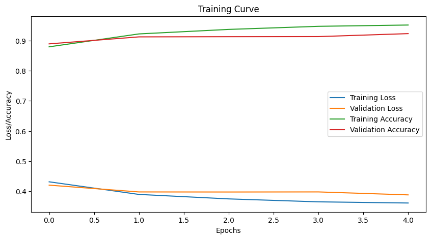

```python
#
n_model = 1 #Model 1 Part B
n_classes = 2
dropout = 0.3
lr = 1e-5
num_epochs = 5  # Choose the number of epochs
batch_size = 8

model = SentimentClassifierPooled(n_classes=n_classes)
# Train the model
train_network_B(model, bs = batch_size,train_loader=train_data_loader, valid_loader=val_data_loader,
                n_model=n_model,lr=lr,num_epochs=num_epochs)
```

```python
""""import json

with open("/var/log/colab-jupyter.log", "r") as fo:
  for line in fo:
    print(json.loads(line)['msg'])""""
```

### Part (iii) [1pt MODEL]

Choose at least 4 hyperparameters to tune. Explain how you tuned the hyperparameters. You don't need to include your training curve for every model you trained. Instead, explain what hyperparemters you tuned, what the best validation accuracy was, and the reasoning behind the hyperparameter decisions you made.

For this assignment, you should tune more than just your learning rate and epoch. Choose at least 2 hyperparameters that are unrelated to the optimizer.

```python
# TO BE COMPLETED
#Model 2, dropped to 0.6, learning rate to 0.01, epoach 4
n_model = 2 #Model 2
n_classes = 2
dropout = 0.3
lr = 0.01
num_epochs = 4
batch_size = 8
```

```python
import torch
import torch.nn as nn
from transformers import BertModel

class SentimentClassifierPooled2(nn.Module):

  def __init__(self, n_classes):
    super(SentimentClassifierPooled2, self).__init__()
    self.name = 'Pooled2'
    self.bert = BertModel.from_pretrained(PRE_TRAINED_MODEL_NAME).to(device)
    self.drop = nn.Dropout(p=0.6)  # Add dropout layer for regularization
    self.out = nn.Linear(in_features=768,out_features=n_classes)
    self.softmax = nn.Softmax(dim=1)

  def forward(self, input_ids, attention_mask):
    pooled_output = self.bert(input_ids=input_ids, attention_mask=attention_mask)[1]
    output = self.drop(pooled_output)  # Applying dropout to pooled output
    output = self.out(output)  # Passing through a linear layer
    return self.softmax(output)  # Applying softmax to obtain class probabilities
```

```
Epoch [1/4], Train Loss: 0.8136, Valid Loss: 0.8111, Train Acc: 0.4996, Valid Acc: 0.5022
Validation loss decreased (0.811062 --> 0.811062).  Saving model ...
Epoch [2/4], Train Loss: 0.8138, Valid Loss: 0.8111, Train Acc: 0.4995, Valid Acc: 0.5022
Epoch [3/4], Train Loss: 0.8138, Valid Loss: 0.8111, Train Acc: 0.4995, Valid Acc: 0.5022
Epoch [4/4], Train Loss: 0.8138, Valid Loss: 0.8111, Train Acc: 0.4995, Valid Acc: 0.5022
```

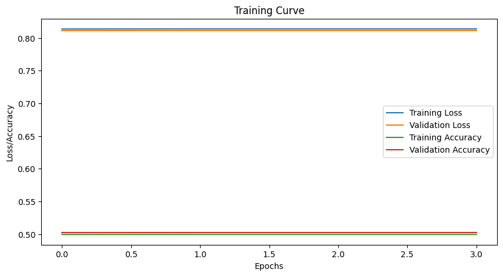

```python
model = SentimentClassifierPooled2(n_classes=n_classes)
# Train the model
train_network_B(model, bs = batch_size,train_loader=train_data_loader, valid_loader=val_data_loader,
                n_model=n_model,lr=lr,num_epochs=num_epochs)
```

```python
'''
PROVIDE YOUR ANSWER BELOW

- For this part it was difficult to modify the hyperameters for the network
  SentimentClassifierPooled2 since it took too much time even with the simplest architecture I was able to
  develop, so no further changes to make more complex architecture were made.
  The pretrained network was already complex and number of layers was already high.
  I only change the dropout from 0.5 to 0.6 to try to make a test a little faster
- With the pretrained model, the results for accuracy was already good with few epochs
  so it was reduced from 5 to 4.
- Also, the batch size was change from 16 to 8 to help the GPU's memory since with
  16 the GPU was not able to support backpropagation.
- Learning Rate: A higher learning rate may lead to faster convergence but risk
  overshooting the minimum; a lower learning rate might be too slow to converge or get stuck in
  local minima as happended with model 3
- Some other changes were made in the training loop to help with memory use such as:
  - use clip to help with backpropagation
      nn.utils.clip_grad_norm_(model.parameters(), clip)
  - use torch.no_grad to disables computing gradients


The best model was the first with batch size 8, learning rate 1e-5, and dropout 0.5
'''
```

[output not shown]

[output not shown]